```python
import pandas as pd
import numpy as np
import matplotlib.pyplot as plt
import seaborn as sns

from sklearn.linear_model import LinearRegression

plt.style.use('seaborn-white')
plt.rc('figure', dpi=100, figsize=(7, 5))
plt.rc('font', size=12)

import warnings
warnings.simplefilter('ignore')
```

# Lecture 23 – Pipelines and Evaluation

## DSC 80, Spring 2022

For fun: read [this article from CBS 8 San Diego](https://www.cbs8.com/article/news/investigations/san-diego-pays-113-million-in-overtime/509-cccb0373-b602-448d-90d7-a40b0f30a2a6) 💰🚒🚔.

> Last year, the city paid \$52.93 million in overtime to the fire department. San Diego Police Department received the second highest out of any other department with \\$36.6 million.

### Announcements

- Discussion 7 is due for extra credit **tomorrow at 11:59PM**.
  - See [this post](https://campuswire.com/c/G325FA25B/feed/1473) for a clarification.
- Lab 8 is due on **Monday, May 23rd at 11:59PM**.
- Project 4 is due **Thursday, May 26th at 11:59PM**.
  - See [this post](https://campuswire.com/c/G325FA25B/feed/1511) for more public tests for Question 5.
- Lab 7 grades are released.
  - See [this post](https://campuswire.com/c/G325FA25B/feed/1515) for more details.

### Agenda

- Models in `sklearn`.
- Pipelines.
- Model evaluation 🧪.

## Models in `sklearn`

### Example: Predicting `'tip'` from `'total_bill'` and `'size'`

```python
tips = sns.load_dataset('tips')
tips.head()
```

|  | total_bill | tip | sex | smoker | day | time | size |
| --- | --- | --- | --- | --- | --- | --- | --- |
| 0 | 16.99 | 1.01 | Female | No | Sun | Dinner | 2 |
| 1 | 10.34 | 1.66 | Male | No | Sun | Dinner | 3 |
| 2 | 21.01 | 3.50 | Male | No | Sun | Dinner | 3 |
| 3 | 23.68 | 3.31 | Male | No | Sun | Dinner | 2 |
| 4 | 24.59 | 3.61 | Female | No | Sun | Dinner | 4 |

First, we instantiate and fit. By calling `fit`, we are saying "minimize mean squared error and find $w^*$".

```python
lr = LinearRegression()

# Note that there are two arguments to fit – X and y!
# (It is not necessary to write X= and y=)
lr.fit(X=tips[['total_bill', 'size']], y=tips['tip'])
```

```
LinearRegression()
```

After fitting, the `predict` method is available. Note that the argument to `predict` can be any 2D array with two columns.

```python
# Predicted tip from a table of 3 that spends $25
lr.predict([[25, 3]])
```

```
array([3.56457154])
```

```python
# Predicted tip from a table of 14 that spends $1000 – probably not accurate!
lr.predict([[1000, 14]])
```

```
array([96.07865069])
```

We can access the intercepts and slopes individually. This model is of the form

$$\text{predicted tip} = w_0^* + w_1^* \cdot \text{total bill} + w_2^* \cdot \text{table size}$$

so we should expect three parameters total.

```python
lr.intercept_
```

```
0.6689447408125031
```

```python
lr.coef_
```

```
array([0.09271334, 0.19259779])
```

If we want to compute the RMSE of our model, we need to find its predictions on every row in the training data (`tips`).

```python
all_preds = lr.predict(tips[['total_bill', 'size']])
```

```python
np.sqrt(np.mean((all_preds - tips['tip']) ** 2))
```

```
1.007256127114662
```

It turns out that fit `LinearRegression` objects also have a `score` method:

```python
lr.score(tips[['total_bill', 'size']], tips['tip'])
```

```
0.46786930879612587
```

That doesn't look like the RMSE... what is it? 🤔

### Aside: $R^2$

- $R^2$, or the **coefficient of determination**, is a measure of the **quality of a linear fit**.
- There are a few equivalent ways of computing it, assuming your model **is linear and has an intercept term**:

$$R^2 = \frac{\text{var}(\text{predicted $y$ values})}{\text{var}(\text{actual $y$ values})}$$$$R^2 = \left[ \text{correlation}(\text{predicted $y$ values}, \text{actual $y$ values}) \right]^2$$

- In the simple linear regression case, it is the square of the correlation coefficient, $r$.
- **Key idea:** $R^2$ ranges from 0 to 1. **The closer it is to 1, the better the linear fit is.**
  - $R^2$ has no units of measurement, unlike RMSE.
- Interpretation: $R^2$ is the **proportion of variance in $y$ that the linear model explains**.

### Calculating $R^2$

Recall, `all_preds` contains the predicted `'tip'` for every data point in `tips`.

```python
tips.head()
```

|  | total_bill | tip | sex | smoker | day | time | size |
| --- | --- | --- | --- | --- | --- | --- | --- |
| 0 | 16.99 | 1.01 | Female | No | Sun | Dinner | 2 |
| 1 | 10.34 | 1.66 | Male | No | Sun | Dinner | 3 |
| 2 | 21.01 | 3.50 | Male | No | Sun | Dinner | 3 |
| 3 | 23.68 | 3.31 | Male | No | Sun | Dinner | 2 |
| 4 | 24.59 | 3.61 | Female | No | Sun | Dinner | 4 |

```python
all_preds[:5]
```

```
array([2.62933992, 2.20539403, 3.19464533, 3.24959215, 3.71915687])
```

**Method 1: $R^2 = \frac{\text{var}(\text{predicted $y$ values})}{\text{var}(\text{actual $y$ values})}$**

```python
np.var(all_preds) / np.var(tips['tip'])
```

```
0.4678693087961252
```

**Method 2:** $R^2 = \left[ \text{correlation}(\text{predicted $y$ values}, \text{actual $y$ values}) \right]^2$

Note: By correlation here, we are referring to $r$.

```python
(np.corrcoef(all_preds, tips['tip'])) ** 2
```

```
array([[1.        , 0.46786931],
       [0.46786931, 1.        ]])
```

**Method 3:** `lr.score`

```python
lr.score(tips[['total_bill', 'size']], tips['tip'])
```

```
0.46786930879612587
```

All three methods provide the same result!

### `LinearRegression` summary

| Property | Example | Description |
| --- | --- | --- |
| Initialize model parameters | `lr = LinearRegression()` | Create (empty) linear regression model |
| Fit the model to the data | `lr.fit(data, responses)` | Determines regression coefficients |
| Use model for prediction | `lr.predict(newdata)` | Use regression line make predictions |
| Evaluate the model | `lr.score(data, responses)` | Calculate the $R^2$ of the LR model |
| Access model attributes | `lr.coef_` | Access the regression coefficients |

*Note:* Once `fit`, estimators like `LinearRegression` are just transformers (`predict` <-> `transform`).

## Pipelines

[figure not shown]

So far, we've used transformers for feature engineering and models for prediction. We can combine these steps into a single `Pipeline`.

### `Pipeline`s in `sklearn`

- A `Pipeline` object is instantiated using a **list** containing transformer(s) and a model (estimator).

  ```
  pl = Pipeline([feat_trans1, feat_trans2, ..., mdl])
  ```

- Once a `Pipeline` is instantiated, you can fit **all** steps (transformers and model) using `fit`.

  ```
  pl.fit(data, responses)
  ```

- To make predictions using **raw (untransformed) data**, use `pl.predict`.

### Creating a `Pipeline`

- To instantiate a `Pipeline`, we must provide a list with zero or more transformers followed by a single model.
  - All "steps" must have `fit` methods, and all but the last must have `transform` methods.
- The list we provide `Pipeline` with must be a list of **tuples**, where
  - The first element is a "name" (that we choose) for the step.
  - The second element is a transformer or estimator instance.

Let's build a `Pipeline` that:

- One-hot-encodes the categorical features in `tips`.
- Fits a regression model on the one-hot-encoded data.

```python
tips_cat = tips[['sex', 'smoker', 'day', 'time']]
tips_cat.head()
```

|  | sex | smoker | day | time |
| --- | --- | --- | --- | --- |
| 0 | Female | No | Sun | Dinner |
| 1 | Male | No | Sun | Dinner |
| 2 | Male | No | Sun | Dinner |
| 3 | Male | No | Sun | Dinner |
| 4 | Female | No | Sun | Dinner |

```python
from sklearn.pipeline import Pipeline
from sklearn.preprocessing import OneHotEncoder
```

```python
pl = Pipeline([
    ('one-hot', OneHotEncoder()),
    ('lin-reg', LinearRegression())
])
```

Now that `pl` is instantiated, we `fit` it the same way we would fit the individual steps.

```python
pl.fit(tips_cat, tips['tip'])
```

```
Pipeline(steps=[('one-hot', OneHotEncoder()), ('lin-reg', LinearRegression())])
```

Now, to make predictions using **raw data**, all we need to do is use `pl.predict`:

```python
pl.predict([['Male', 'Yes', 'Sat', 'Lunch']])
```

```
array([2.58813051])
```

```python
pl.predict(tips_cat.iloc[:5])
```

```
array([3.10415414, 3.27436302, 3.27436302, 3.27436302, 3.10415414])
```

`pl` performs **both** feature transformation and prediction with just a single call to `predict`!

We can access individual "steps" of a `Pipeline` through the `named_steps` attribute:

```python
pl.named_steps
```

```
{'one-hot': OneHotEncoder(), 'lin-reg': LinearRegression()}
```

```python
pl.named_steps['one-hot'].transform(tips_cat).toarray()
```

```
array([[1., 0., 1., ..., 0., 1., 0.],
       [0., 1., 1., ..., 0., 1., 0.],
       [0., 1., 1., ..., 0., 1., 0.],
       ...,
       [0., 1., 0., ..., 0., 1., 0.],
       [0., 1., 1., ..., 0., 1., 0.],
       [1., 0., 1., ..., 1., 1., 0.]])
```

```python
pl.named_steps['lin-reg'].coef_
```

```
array([-0.08510444,  0.08510444, -0.04216238,  0.04216238, -0.20256076,
       -0.12962763,  0.13756057,  0.19462781,  0.25168453, -0.25168453])
```

### More sophisticated `Pipeline`s

- In the previous example, we one-hot-encoded every input column. **What if we want to perform different transformations on different columns?**
- **Solution:** Use a `ColumnTransformer`.
  - Instantiate a `ColumnTransformer` using a list of tuples, where:
    - The first element is a "name" we choose for the transformer.
    - The second element is a transformer instance (e.g. `OneHotEncoder()`).
    - The third element is a **list of relevant column names**.
  - `ColumnTransformer` is extremely useful, but it was only added to `sklearn` in 2018!

[figure not shown]

```python
from sklearn.compose import ColumnTransformer
from sklearn.preprocessing import StandardScaler
```

Let's perform different transformations on the quantitative and categorical features of `tips` (so, we will not transform `'tip'`).

```python
tips_features = tips.drop('tip', axis=1)
tips_features.head()
```

|  | total_bill | sex | smoker | day | time | size |
| --- | --- | --- | --- | --- | --- | --- |
| 0 | 16.99 | Female | No | Sun | Dinner | 2 |
| 1 | 10.34 | Male | No | Sun | Dinner | 3 |
| 2 | 21.01 | Male | No | Sun | Dinner | 3 |
| 3 | 23.68 | Male | No | Sun | Dinner | 2 |
| 4 | 24.59 | Female | No | Sun | Dinner | 4 |

- To the **quantitative features (`'total_bill'` and `'size'`)**, we will apply the `StandardScaler` transformer.
- To the **categorical features**, we will apply the `OneHotEncoder` transformer.

```python
preproc = ColumnTransformer(
    transformers = [
        ('quant', StandardScaler(), ['total_bill', 'size']),
        ('cat', OneHotEncoder(), ['sex', 'smoker', 'day', 'time'])
    ]
)
```

Now, let's create a `Pipeline` using `preproc` as a transformer, and `fit` it:

```python
pl = Pipeline([
    ('preprocessor', preproc),
    ('lin-reg', LinearRegression())
])
```

```python
pl.fit(tips_features, tips['tip'])
```

```
Pipeline(steps=[('preprocessor',
                 ColumnTransformer(transformers=[('quant', StandardScaler(),
                                                  ['total_bill', 'size']),
                                                 ('cat', OneHotEncoder(),
                                                  ['sex', 'smoker', 'day',
                                                   'time'])])),
                ('lin-reg', LinearRegression())])
```

Prediction is as easy as calling `predict`:

```python
tips_features.head()
```

|  | total_bill | sex | smoker | day | time | size |
| --- | --- | --- | --- | --- | --- | --- |
| 0 | 16.99 | Female | No | Sun | Dinner | 2 |
| 1 | 10.34 | Male | No | Sun | Dinner | 3 |
| 2 | 21.01 | Male | No | Sun | Dinner | 3 |
| 3 | 23.68 | Male | No | Sun | Dinner | 2 |
| 4 | 24.59 | Female | No | Sun | Dinner | 4 |

```python
pl.predict(tips_features.head())
```

```
array([2.73565486, 2.25086733, 3.25904369, 3.33533199, 3.80574011])
```

`pl` also has a `score` method, the same way a fit `LinearRegression` instance does:

```python
pl.score(tips_features, tips['tip'])
```

```
0.47007812322060794
```

Recall, we can access the individual "steps" in `pl` using the `named_steps` attribute:

```python
pl.named_steps['preprocessor'].transform(tips_features)
```

```
array([[-0.31471131, -0.60019263,  1.        , ...,  0.        ,
         1.        ,  0.        ],
       [-1.06323531,  0.45338292,  0.        , ...,  0.        ,
         1.        ,  0.        ],
       [ 0.1377799 ,  0.45338292,  0.        , ...,  0.        ,
         1.        ,  0.        ],
       ...,
       [ 0.3246295 , -0.60019263,  0.        , ...,  0.        ,
         1.        ,  0.        ],
       [-0.2212865 , -0.60019263,  0.        , ...,  0.        ,
         1.        ,  0.        ],
       [-0.1132289 , -0.60019263,  1.        , ...,  1.        ,
         1.        ,  0.        ]])
```

**Note:** `ColumnTransformer` has a `remainder` argument that you can use to specify what to do with columns that aren't being transfromed (`'drop'` or `'passthrough'`).

## Model evaluation 🧪

### Motivation

- You and Billy are studying for an upcoming exam. You both decide to test your understanding by taking a **practice exam**.
  - Your logic: If you do well on the practice exam, you should do well on the real exam.
- You each take the practice exam once and look at the solutions afterwards.
- **Your strategy:** Memorize the answers to all practice exam questions, e.g. "Question 1: A; Question 2: C; Question 3: A."
- **Billy's strategy:** Learn high-level concepts from the solutions, e.g. "data are NMAR if the likelihood of missingness depends on the missing values themselves."
- Who will do better on the **practice exam**? Who will probably do better on the **real exam**? 🧐

### Evaluating the quality of a model

- So far, we've computed the RMSE (and $R^2$) of our fit regression models on the **data that we used to fit them**, i.e. the **training data**.
- We've said that Model A is **better** than Model B if Model A's RMSE is **lower** than Model B's RMSE.
  - Remember, our **training data** is a sample from the data generating process.
  - Just because a model fits the training data well doesn't mean it will **generalize** and work well on **similar, unseen samples**!

### Example: Overfitting and underfitting

Let's collect two samples $\{(x_i, y_i)\}$ from the same **data generating process**.

```python
np.random.seed(23) # For reproducibility

def sample_dgp(n=100):
    x = np.linspace(-2, 3, n)
    y = x ** 3 + (np.random.normal(0, 3, size=n))
    return x.reshape(-1, 1), y

x1, y1 = sample_dgp()
x2, y2 = sample_dgp()
```

For now, let's just look at Sample 1. The relationship between $x$ and $y$ is roughly **cubic**; that is, $y \approx x^3$ (remember, in reality, you won't get to see the DGP).

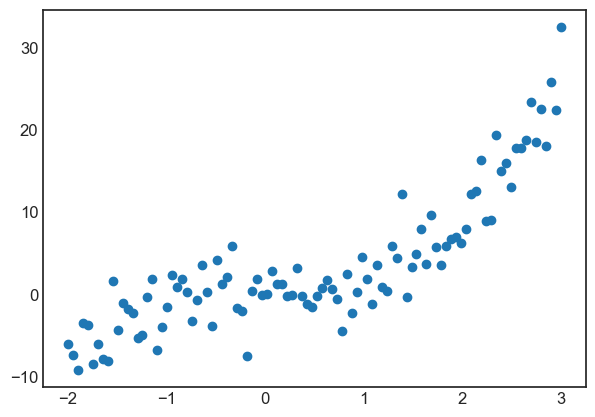

```python
plt.scatter(x1, y1);
```

Let's fit three **polynomial** models on Sample 1:

- Degree 1.
- Degree 3.
- Degree 15.

The `PolynomialFeatures` transformer will be helpful here.

```python
from sklearn.preprocessing import PolynomialFeatures
```

```python
d2 = PolynomialFeatures(3)
d2.fit_transform([[1], [2], [3], [4], [5]]) # fit_transform fits and transforms the same input
```

```
array([[  1.,   1.,   1.,   1.],
       [  1.,   2.,   4.,   8.],
       [  1.,   3.,   9.,  27.],
       [  1.,   4.,  16.,  64.],
       [  1.,   5.,  25., 125.]])
```

```python
degs = [1, 3, 15]

def fit_polys(x, y):
    # Create all three Pipelines
    pls = [
        Pipeline([('poly', PolynomialFeatures(d)), ('lin-reg', LinearRegression())])
        for d in degs
    ]

    # Fit all three Pipelines
    [pl.fit(x, y) for pl in pls];

    # Make all three sets of predictions
    preds = [pl.predict(x) for pl in pls]
    return preds

preds_1 = fit_polys(x1, y1)
```

Below, we look at our three models' predictions on Sample 1 (which they were trained on).

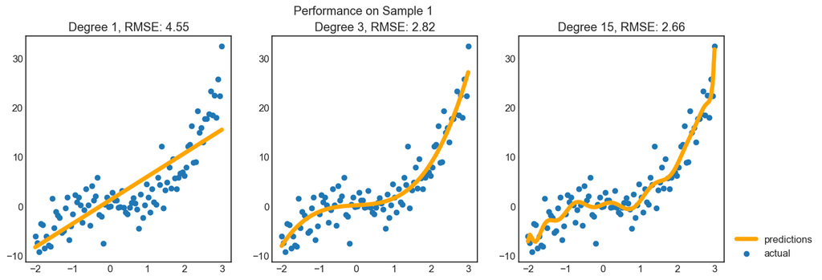

```python
plt.subplots(1, 3, figsize=(15, 5), dpi=100)
plt.suptitle('Performance on Sample 1\n')

for i in range(1, 4):
    plt.subplot(1, 3, i)
    plt.scatter(x1, y1, label='actual')
    plt.plot(x1, preds_1[i-1], color='orange', label='predictions', linewidth=5)
    rmse_d = np.sqrt(np.mean((preds_1[i-1] - y1) ** 2))
    plt.title(f'Degree {degs[i-1]}, RMSE: {np.round(rmse_d, 2)}')
plt.legend(loc=(1.04, 0))
plt.show()
```

The degree 15 polynomial has the lowest RMSE on Sample 1.

How do things look in Sample 2?

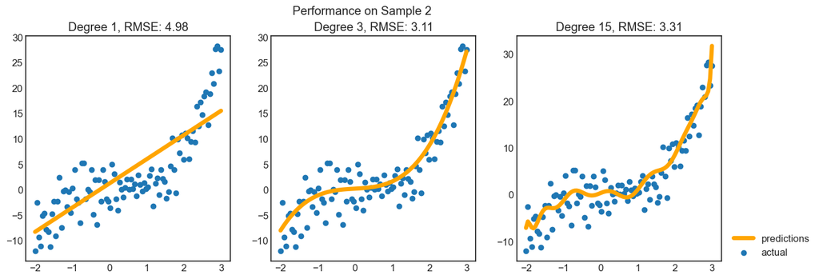

```python
plt.subplots(1, 3, figsize=(15, 5), dpi=100)
plt.suptitle('Performance on Sample 2\n')

for i in range(1, 4):
    plt.subplot(1, 3, i)
    plt.scatter(x2, y2, label='actual')
    plt.plot(x1, preds_1[i-1], color='orange', label='predictions', linewidth=5)
    rmse_d = np.sqrt(np.mean((preds_1[i-1] - y2) ** 2))
    plt.title(f'Degree {degs[i-1]}, RMSE: {np.round(rmse_d, 2)}')
plt.legend(loc=(1.04, 0))
plt.show()
```

- The degree 3 polynomial has the lowest RMSE on Sample 2.
- Note that **we didn't get to see Sample 2 when fitting our models**!
- As such, it seems that the degree 3 polynomial **generalizes better** to unseen data than the degree 15 polynomial does.

What if we fit a degree 1, degree 3, and degree 15 polynomial **on Sample 2** as well?

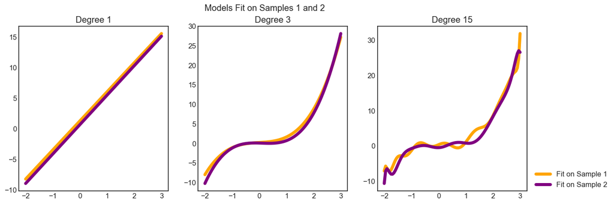

```python
preds_2 = fit_polys(x2, y2)

plt.subplots(1, 3, figsize=(15, 5), dpi=100)
plt.suptitle('Models Fit on Samples 1 and 2\n')

for i in range(1, 4):
    plt.subplot(1, 3, i)
#     plt.scatter(x2, y2, label='actual')
    plt.plot(x1, preds_1[i-1], color='orange', label='Fit on Sample 1', linewidth=5)
    plt.plot(x2, preds_2[i-1], color='purple', label='Fit on Sample 2', linewidth=5)
    plt.title(f'Degree {degs[i-1]}')
plt.legend(loc=(1.04, 0))
plt.show()
```

**Key idea:** The degree 15 polynomial seems to **vary more** than the degree 3 and 1 polynomials do.

### Bias and variance

The training data we have access to is a sample from the DGP. We are concerned with our model's performance **across different datasets** from the same DGP.

Suppose we **fit** a model $H$ (e.g. a degree 3 polynomial) on **several different datasets** from a DGP. There are three sources of error that arise:

- ⭐️ **Bias**: **The expected deviation between a predicted value and an actual value**.
  - In other words, **for a given $x_i$, how far is $H(x_i)$ from the true $y_i$, on average?**
  - Low bias is good! ✅
  - High bias is a sign of **underfitting**, i.e. that our model is too **basic** to capture the relationship between our features and response.
- ⭐️ **Model variance ("variance")**: **The variance of a model's predictions**.
  - In other words, **for a given $x_i$, what is the variance of $H(x_i)$ across all datasets**?
  - Low model variance is good! ✅
  - High model variance is a sign of **overfitting**, i.e. that our model is too **complicated** and is prone to fitting to the noise in our training data.
- **Observation variance**: The variance due to the random noise in the process we are trying to model (e.g. measurement error). *We can't control this, without collecting more data!*

Here, suppose

- the red bulls-eye represents your **true weight and height** 🧍, and
- the blue darts represent **predictions of your weight and height** using different models that were fit on the same DGP.

[figure not shown]

### Avoiding overfitting

- We won't know whether our model has **overfit** to our sample (training data) unless we get to see how well it performs on a new sample from the same DGP.
- **Idea 💡:** **Split** our sample into a **training set** and **test set**.
- Use **only** the training set to fit the model (i.e. find $w^*$).
- Use the test set to evaluate the model's error (RMSE, $R^2$).
- This is like "generating" new data from the same DGP!
  - *Similar* to bootstrapping (but not quite the same, because there is no resampling involved).
  - **If our sample is not representative of the DGP, this method has limited effectiveness!**

[figure not shown]

### Train-test split 🚆

`sklearn.model_selection.train_test_split` implements a train-test split for us! 🙏🏼

If `X` is an array/DataFrame of features and `y` is an array/Series of responses,

```
X_train, X_test, y_train, y_test = train_test_split(X, y, test_size=0.25)
```

randomly splits the features and responses into training and test sets, such that the test set contains 0.25 of the full dataset.

```python
from sklearn.model_selection import train_test_split
```

```python
# Read the documentation!
train_test_split?
```

Let's perform a train/test split on our `tips` dataset.

```python
X = tips.drop('tip', axis=1)
y = tips['tip']
X_train, X_test, y_train, y_test = train_test_split(X, y, test_size=0.2) # Don't have to choose 0.25
```

Before proceeding, let's check the sizes of `X_train` and `X_test`.

```python
print('Rows in X_train:', X_train.shape[0])
display(X_train.head())
print('Rows in X_test:', X_test.shape[0])
display(X_test.head())
```

```
Rows in X_train: 195
```

|  | total_bill | sex | smoker | day | time | size |
| --- | --- | --- | --- | --- | --- | --- |
| 4 | 24.59 | Female | No | Sun | Dinner | 4 |
| 209 | 12.76 | Female | Yes | Sat | Dinner | 2 |
| 178 | 9.60 | Female | Yes | Sun | Dinner | 2 |
| 230 | 24.01 | Male | Yes | Sat | Dinner | 4 |
| 5 | 25.29 | Male | No | Sun | Dinner | 4 |

```
Rows in X_test: 49
```

|  | total_bill | sex | smoker | day | time | size |
| --- | --- | --- | --- | --- | --- | --- |
| 146 | 18.64 | Female | No | Thur | Lunch | 3 |
| 224 | 13.42 | Male | Yes | Fri | Lunch | 2 |
| 134 | 18.26 | Female | No | Thur | Lunch | 2 |
| 131 | 20.27 | Female | No | Thur | Lunch | 2 |
| 147 | 11.87 | Female | No | Thur | Lunch | 2 |

```python
X_train.shape[0] / tips.shape[0]
```

```
0.7991803278688525
```

### Example prediction pipeline

Steps:

- Fit a model on the training set.
- Evaluate the model on the test set.

```python
X = tips[['total_bill', 'size']] # For this example, we'll use just the already-quantitative columns in tips
y = tips['tip']
X_train, X_test, y_train, y_test = train_test_split(X, y, test_size=0.2)
```

Here, we'll use a stand-alone `LinearRegression` model without a `Pipeline`, but this process would work the same if we were using a `Pipeline`.

```python
lr = LinearRegression()
lr.fit(X_train, y_train)
```

```
LinearRegression()
```

Let's check our model's performance on the **training** set first.

```python
pred_train = lr.predict(X_train)
rmse_train = np.sqrt(np.mean((pred_train - y_train) ** 2))
rmse_train
```

```
1.0142193530579229
```

And the **test** set:

```python
pred_test = lr.predict(X_test)
rmse_test = np.sqrt(np.mean((pred_test - y_test) ** 2))
rmse_test
```

```
0.983914318376069
```

Since `rmse_train` and `rmse_test` are similar, it **doesn't seem like our model is overfitting** to the training data. If `rmse_test` was much larger than `rmse_train`, it would be evidence that our model is unable to **generalize well**.

## Summary, next time

### Summary

- $R^2$ is a measure of a model's "goodness-of-fit". For linear models, it ranges between 0 (poor) and 1 (great).
- `Pipeline`s in `sklearn` combine one or more transformers with a single model (estimator), allowing us to perform feature engineering and prediction through a single object.
- We want to build models that **generalize well** to unseen data.
  - Models that have high **bias** are too simple to represent complex relationships in data, and **underfit**.
  - Models that have high **variance** are overly complex for the relationships in the data, and vary a lot when fit on different datasets. Such models **overfit** to the training data.
- In order to prevent overfitting, we should perform a **train-test split** in which we only train our model on a subset of the data available to us, and use the remainder for evaluation.